# Risk Factor Analysis

## Outcome Variable

**Outcome Variable:** y_rate_len

## Predictor Variables

**Intervention Variable:** nchldlt5

**Adjustment Set:**

unadjusted

## Stratifying Variables

The analysis was stratified on these variable(s):

- agecat
- studyid
- country

## Data Summary

| agecat | studyid | country | nchldlt5 | n_cell | n |
| --- | --- | --- | --- | --- | --- |
| 0-3 months | ki1017093b-PROVIDE | BANGLADESH | 1 | 467 | 634 |
| 0-3 months | ki1017093b-PROVIDE | BANGLADESH | 2 | 158 | 634 |
| 0-3 months | ki1017093b-PROVIDE | BANGLADESH | 3+ | 9 | 634 |
| 0-3 months | ki1017093c-NIH-Crypto | BANGLADESH | 1 | 511 | 720 |
| 0-3 months | ki1017093c-NIH-Crypto | BANGLADESH | 2 | 203 | 720 |
| 0-3 months | ki1017093c-NIH-Crypto | BANGLADESH | 3+ | 6 | 720 |
| 0-3 months | kiGH5241-JiVitA-3 | BANGLADESH | 1 | 12472 | 20027 |
| 0-3 months | kiGH5241-JiVitA-3 | BANGLADESH | 2 | 7095 | 20027 |
| 0-3 months | kiGH5241-JiVitA-3 | BANGLADESH | 3+ | 460 | 20027 |
| 0-3 months | ki1000108-IRC | INDIA | 1 | 82 | 377 |
| 0-3 months | ki1000108-IRC | INDIA | 2 | 109 | 377 |
| 0-3 months | ki1000108-IRC | INDIA | 3+ | 186 | 377 |
| 3-6 months | ki1017093b-PROVIDE | BANGLADESH | 1 | 421 | 574 |
| 3-6 months | ki1017093b-PROVIDE | BANGLADESH | 2 | 145 | 574 |
| 3-6 months | ki1017093b-PROVIDE | BANGLADESH | 3+ | 8 | 574 |
| 3-6 months | ki1017093c-NIH-Crypto | BANGLADESH | 1 | 492 | 695 |
| 3-6 months | ki1017093c-NIH-Crypto | BANGLADESH | 2 | 198 | 695 |
| 3-6 months | ki1017093c-NIH-Crypto | BANGLADESH | 3+ | 5 | 695 |
| 3-6 months | kiGH5241-JiVitA-3 | BANGLADESH | 1 | 8102 | 12571 |
| 3-6 months | kiGH5241-JiVitA-3 | BANGLADESH | 2 | 4211 | 12571 |
| 3-6 months | kiGH5241-JiVitA-3 | BANGLADESH | 3+ | 258 | 12571 |
| 3-6 months | ki1000108-IRC | INDIA | 1 | 87 | 397 |
| 3-6 months | ki1000108-IRC | INDIA | 2 | 114 | 397 |
| 3-6 months | ki1000108-IRC | INDIA | 3+ | 196 | 397 |
| 3-6 months | ki1066203-TanzaniaChild2 | TANZANIA, UNITED REPUBLIC OF | 1 | 1145 | 1655 |
| 3-6 months | ki1066203-TanzaniaChild2 | TANZANIA, UNITED REPUBLIC OF | 2 | 461 | 1655 |
| 3-6 months | ki1066203-TanzaniaChild2 | TANZANIA, UNITED REPUBLIC OF | 3+ | 49 | 1655 |
| 6-12 months | ki1017093b-PROVIDE | BANGLADESH | 1 | 399 | 545 |
| 6-12 months | ki1017093b-PROVIDE | BANGLADESH | 2 | 138 | 545 |
| 6-12 months | ki1017093b-PROVIDE | BANGLADESH | 3+ | 8 | 545 |
| 6-12 months | ki1017093c-NIH-Crypto | BANGLADESH | 1 | 474 | 676 |
| 6-12 months | ki1017093c-NIH-Crypto | BANGLADESH | 2 | 198 | 676 |
| 6-12 months | ki1017093c-NIH-Crypto | BANGLADESH | 3+ | 4 | 676 |
| 6-12 months | kiGH5241-JiVitA-3 | BANGLADESH | 1 | 6298 | 9831 |
| 6-12 months | kiGH5241-JiVitA-3 | BANGLADESH | 2 | 3328 | 9831 |
| 6-12 months | kiGH5241-JiVitA-3 | BANGLADESH | 3+ | 205 | 9831 |
| 6-12 months | ki1000108-IRC | INDIA | 1 | 88 | 400 |
| 6-12 months | ki1000108-IRC | INDIA | 2 | 116 | 400 |
| 6-12 months | ki1000108-IRC | INDIA | 3+ | 196 | 400 |
| 6-12 months | ki1148112-LCNI-5 | MALAWI | 1 | 205 | 428 |
| 6-12 months | ki1148112-LCNI-5 | MALAWI | 2 | 195 | 428 |
| 6-12 months | ki1148112-LCNI-5 | MALAWI | 3+ | 28 | 428 |
| 6-12 months | ki1066203-TanzaniaChild2 | TANZANIA, UNITED REPUBLIC OF | 1 | 769 | 1077 |
| 6-12 months | ki1066203-TanzaniaChild2 | TANZANIA, UNITED REPUBLIC OF | 2 | 279 | 1077 |
| 6-12 months | ki1066203-TanzaniaChild2 | TANZANIA, UNITED REPUBLIC OF | 3+ | 29 | 1077 |
| 12-24 months | ki1017093b-PROVIDE | BANGLADESH | 1 | 331 | 458 |
| 12-24 months | ki1017093b-PROVIDE | BANGLADESH | 2 | 121 | 458 |
| 12-24 months | ki1017093b-PROVIDE | BANGLADESH | 3+ | 6 | 458 |
| 12-24 months | ki1017093c-NIH-Crypto | BANGLADESH | 1 | 341 | 495 |
| 12-24 months | ki1017093c-NIH-Crypto | BANGLADESH | 2 | 151 | 495 |
| 12-24 months | ki1017093c-NIH-Crypto | BANGLADESH | 3+ | 3 | 495 |
| 12-24 months | kiGH5241-JiVitA-3 | BANGLADESH | 1 | 2907 | 4647 |
| 12-24 months | kiGH5241-JiVitA-3 | BANGLADESH | 2 | 1627 | 4647 |
| 12-24 months | kiGH5241-JiVitA-3 | BANGLADESH | 3+ | 113 | 4647 |
| 12-24 months | ki1000108-IRC | INDIA | 1 | 86 | 396 |
| 12-24 months | ki1000108-IRC | INDIA | 2 | 116 | 396 |
| 12-24 months | ki1000108-IRC | INDIA | 3+ | 194 | 396 |
| 12-24 months | ki1148112-LCNI-5 | MALAWI | 1 | 152 | 306 |
| 12-24 months | ki1148112-LCNI-5 | MALAWI | 2 | 135 | 306 |
| 12-24 months | ki1148112-LCNI-5 | MALAWI | 3+ | 19 | 306 |
| 12-24 months | ki1066203-TanzaniaChild2 | TANZANIA, UNITED REPUBLIC OF | 1 | 1 | 2 |
| 12-24 months | ki1066203-TanzaniaChild2 | TANZANIA, UNITED REPUBLIC OF | 2 | 1 | 2 |

The following strata were considered:

- agecat: 0-3 months, studyid: ki1000108-IRC, country: INDIA
- agecat: 0-3 months, studyid: ki1017093b-PROVIDE, country: BANGLADESH
- agecat: 0-3 months, studyid: ki1017093c-NIH-Crypto, country: BANGLADESH
- agecat: 0-3 months, studyid: kiGH5241-JiVitA-3, country: BANGLADESH
- agecat: 12-24 months, studyid: ki1000108-IRC, country: INDIA
- agecat: 12-24 months, studyid: ki1017093b-PROVIDE, country: BANGLADESH
- agecat: 12-24 months, studyid: ki1017093c-NIH-Crypto, country: BANGLADESH
- agecat: 12-24 months, studyid: ki1066203-TanzaniaChild2, country: TANZANIA, UNITED REPUBLIC OF
- agecat: 12-24 months, studyid: ki1148112-LCNI-5, country: MALAWI
- agecat: 12-24 months, studyid: kiGH5241-JiVitA-3, country: BANGLADESH
- agecat: 3-6 months, studyid: ki1000108-IRC, country: INDIA
- agecat: 3-6 months, studyid: ki1017093b-PROVIDE, country: BANGLADESH
- agecat: 3-6 months, studyid: ki1017093c-NIH-Crypto, country: BANGLADESH
- agecat: 3-6 months, studyid: ki1066203-TanzaniaChild2, country: TANZANIA, UNITED REPUBLIC OF
- agecat: 3-6 months, studyid: kiGH5241-JiVitA-3, country: BANGLADESH
- agecat: 6-12 months, studyid: ki1000108-IRC, country: INDIA
- agecat: 6-12 months, studyid: ki1017093b-PROVIDE, country: BANGLADESH
- agecat: 6-12 months, studyid: ki1017093c-NIH-Crypto, country: BANGLADESH
- agecat: 6-12 months, studyid: ki1066203-TanzaniaChild2, country: TANZANIA, UNITED REPUBLIC OF
- agecat: 6-12 months, studyid: ki1148112-LCNI-5, country: MALAWI
- agecat: 6-12 months, studyid: kiGH5241-JiVitA-3, country: BANGLADESH

### Dropped Strata

Some strata were dropped due to rare outcomes:

- agecat: 6-12 months, studyid: ki1017093c-NIH-Crypto, country: BANGLADESH
- agecat: 12-24 months, studyid: ki1017093c-NIH-Crypto, country: BANGLADESH
- agecat: 12-24 months, studyid: ki1066203-TanzaniaChild2, country: TANZANIA, UNITED REPUBLIC OF

## Methods Detail

We’re interested in the causal parameters $E[Y_a]$ for all values of $a \in \mathcal{A}$. These parameters represent the mean outcome if, possibly contrary to fact, we intervened to set all units to have $A=a$. Under the randomization and positivity assumptions, these are identified by the statistical parameters $\psi_a=E_W[E_{Y|A,W}(Y|A=a,W)]$. In addition, we’re interested in the mean of $Y$, $E[Y]$ under no intervention (the observed mean). We will estimate these parameters by using SuperLearner to fit the relevant likelihood factors – $E_{Y|A,W}(Y|A=a,W)$ and $p(A=a|W)$, and then updating our likelihood fit using a joint TMLE.

For unadjusted analyses ($W=\{\}$), initial likelihoods were estimated using Lrnr_glm to estimate the simple $E(Y|A)$ and Lrnr_mean to estimate $p(A)$. For adjusted analyses, a small library containing Lrnr_glmnet, Lrnr_xgboost, and Lrnr_mean was used.

# Results Detail

## Results Plots

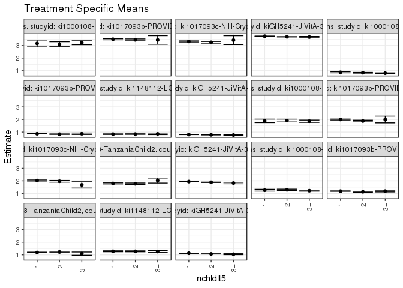

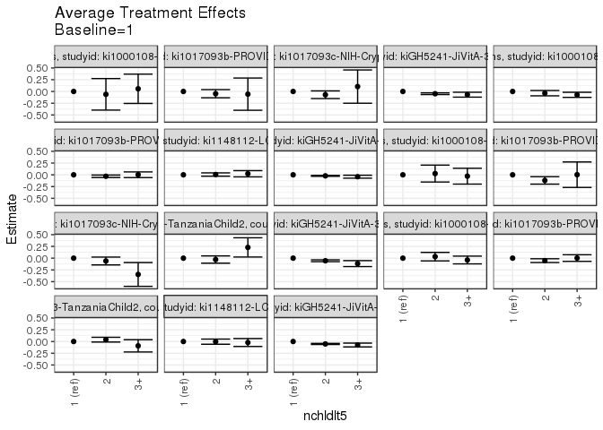

## Results Table

### Parameter: TSM

| agecat | studyid | country | intervention_level | baseline_level | estimate | ci_lower | ci_upper |
| --- | --- | --- | --- | --- | --- | --- | --- |
| 0-3 months | ki1000108-IRC | INDIA | 1 | NA | 3.1624604 | 2.8916221 | 3.4332988 |
| 0-3 months | ki1000108-IRC | INDIA | 2 | NA | 3.1014800 | 2.9038654 | 3.2990946 |
| 0-3 months | ki1000108-IRC | INDIA | 3+ | NA | 3.2193974 | 3.0653555 | 3.3734392 |
| 0-3 months | ki1017093b-PROVIDE | BANGLADESH | 1 | NA | 3.4953761 | 3.4488394 | 3.5419128 |
| 0-3 months | ki1017093b-PROVIDE | BANGLADESH | 2 | NA | 3.4476510 | 3.3742857 | 3.5210164 |
| 0-3 months | ki1017093b-PROVIDE | BANGLADESH | 3+ | NA | 3.4381842 | 3.0983356 | 3.7780327 |
| 0-3 months | ki1017093c-NIH-Crypto | BANGLADESH | 1 | NA | 3.3215718 | 3.2751546 | 3.3679891 |
| 0-3 months | ki1017093c-NIH-Crypto | BANGLADESH | 2 | NA | 3.2521544 | 3.1849412 | 3.3193676 |
| 0-3 months | ki1017093c-NIH-Crypto | BANGLADESH | 3+ | NA | 3.4254477 | 3.0746720 | 3.7762234 |
| 0-3 months | kiGH5241-JiVitA-3 | BANGLADESH | 1 | NA | 3.7370734 | 3.7248869 | 3.7492598 |
| 0-3 months | kiGH5241-JiVitA-3 | BANGLADESH | 2 | NA | 3.6890005 | 3.6733405 | 3.7046605 |
| 0-3 months | kiGH5241-JiVitA-3 | BANGLADESH | 3+ | NA | 3.6686748 | 3.6165559 | 3.7207937 |
| 3-6 months | ki1000108-IRC | INDIA | 1 | NA | 1.8874100 | 1.7469248 | 2.0278952 |
| 3-6 months | ki1000108-IRC | INDIA | 2 | NA | 1.9139784 | 1.8016289 | 2.0263278 |
| 3-6 months | ki1000108-IRC | INDIA | 3+ | NA | 1.8583128 | 1.7660241 | 1.9506015 |
| 3-6 months | ki1017093b-PROVIDE | BANGLADESH | 1 | NA | 1.9955268 | 1.9544752 | 2.0365783 |
| 3-6 months | ki1017093b-PROVIDE | BANGLADESH | 2 | NA | 1.8763128 | 1.8087740 | 1.9438515 |
| 3-6 months | ki1017093b-PROVIDE | BANGLADESH | 3+ | NA | 1.9979433 | 1.7300619 | 2.2658248 |
| 3-6 months | ki1017093c-NIH-Crypto | BANGLADESH | 1 | NA | 2.0255186 | 1.9832633 | 2.0677739 |
| 3-6 months | ki1017093c-NIH-Crypto | BANGLADESH | 2 | NA | 1.9650444 | 1.8931105 | 2.0369784 |
| 3-6 months | ki1017093c-NIH-Crypto | BANGLADESH | 3+ | NA | 1.6790308 | 1.4291721 | 1.9288894 |
| 3-6 months | ki1066203-TanzaniaChild2 | TANZANIA, UNITED REPUBLIC OF | 1 | NA | 1.7948652 | 1.7508397 | 1.8388908 |
| 3-6 months | ki1066203-TanzaniaChild2 | TANZANIA, UNITED REPUBLIC OF | 2 | NA | 1.7651754 | 1.7013371 | 1.8290138 |
| 3-6 months | ki1066203-TanzaniaChild2 | TANZANIA, UNITED REPUBLIC OF | 3+ | NA | 2.0236165 | 1.8241147 | 2.2231184 |
| 3-6 months | kiGH5241-JiVitA-3 | BANGLADESH | 1 | NA | 1.9410703 | 1.9284568 | 1.9536838 |
| 3-6 months | kiGH5241-JiVitA-3 | BANGLADESH | 2 | NA | 1.8859467 | 1.8692139 | 1.9026795 |
| 3-6 months | kiGH5241-JiVitA-3 | BANGLADESH | 3+ | NA | 1.8252080 | 1.7640607 | 1.8863553 |
| 6-12 months | ki1000108-IRC | INDIA | 1 | NA | 1.2585574 | 1.1853263 | 1.3317885 |
| 6-12 months | ki1000108-IRC | INDIA | 2 | NA | 1.2909348 | 1.2380549 | 1.3438147 |
| 6-12 months | ki1000108-IRC | INDIA | 3+ | NA | 1.2190063 | 1.1807894 | 1.2572231 |
| 6-12 months | ki1017093b-PROVIDE | BANGLADESH | 1 | NA | 1.1864243 | 1.1661725 | 1.2066760 |
| 6-12 months | ki1017093b-PROVIDE | BANGLADESH | 2 | NA | 1.1339721 | 1.0997455 | 1.1681986 |
| 6-12 months | ki1017093b-PROVIDE | BANGLADESH | 3+ | NA | 1.1886993 | 1.1209334 | 1.2564652 |
| 6-12 months | ki1066203-TanzaniaChild2 | TANZANIA, UNITED REPUBLIC OF | 1 | NA | 1.1889549 | 1.1637398 | 1.2141700 |
| 6-12 months | ki1066203-TanzaniaChild2 | TANZANIA, UNITED REPUBLIC OF | 2 | NA | 1.2282997 | 1.1844146 | 1.2721847 |
| 6-12 months | ki1066203-TanzaniaChild2 | TANZANIA, UNITED REPUBLIC OF | 3+ | NA | 1.0969297 | 0.9689871 | 1.2248723 |
| 6-12 months | ki1148112-LCNI-5 | MALAWI | 1 | NA | 1.2836292 | 1.2447875 | 1.3224709 |
| 6-12 months | ki1148112-LCNI-5 | MALAWI | 2 | NA | 1.2806779 | 1.2416898 | 1.3196660 |
| 6-12 months | ki1148112-LCNI-5 | MALAWI | 3+ | NA | 1.2620090 | 1.1872631 | 1.3367550 |
| 6-12 months | kiGH5241-JiVitA-3 | BANGLADESH | 1 | NA | 1.1261971 | 1.1180975 | 1.1342966 |
| 6-12 months | kiGH5241-JiVitA-3 | BANGLADESH | 2 | NA | 1.0740639 | 1.0640592 | 1.0840686 |
| 6-12 months | kiGH5241-JiVitA-3 | BANGLADESH | 3+ | NA | 1.0514887 | 1.0117745 | 1.0912028 |
| 12-24 months | ki1000108-IRC | INDIA | 1 | NA | 0.8751557 | 0.8284150 | 0.9218964 |
| 12-24 months | ki1000108-IRC | INDIA | 2 | NA | 0.8390723 | 0.8078270 | 0.8703176 |
| 12-24 months | ki1000108-IRC | INDIA | 3+ | NA | 0.8035085 | 0.7756906 | 0.8313263 |
| 12-24 months | ki1017093b-PROVIDE | BANGLADESH | 1 | NA | 0.8657367 | 0.8512427 | 0.8802307 |
| 12-24 months | ki1017093b-PROVIDE | BANGLADESH | 2 | NA | 0.8346817 | 0.8132887 | 0.8560746 |
| 12-24 months | ki1017093b-PROVIDE | BANGLADESH | 3+ | NA | 0.8672424 | 0.8084526 | 0.9260322 |
| 12-24 months | ki1148112-LCNI-5 | MALAWI | 1 | NA | 0.8364357 | 0.8119534 | 0.8609181 |
| 12-24 months | ki1148112-LCNI-5 | MALAWI | 2 | NA | 0.8424221 | 0.8171444 | 0.8676999 |
| 12-24 months | ki1148112-LCNI-5 | MALAWI | 3+ | NA | 0.8592054 | 0.7974058 | 0.9210049 |
| 12-24 months | kiGH5241-JiVitA-3 | BANGLADESH | 1 | NA | 0.8054683 | 0.7986825 | 0.8122540 |
| 12-24 months | kiGH5241-JiVitA-3 | BANGLADESH | 2 | NA | 0.7833817 | 0.7753633 | 0.7914002 |
| 12-24 months | kiGH5241-JiVitA-3 | BANGLADESH | 3+ | NA | 0.7652827 | 0.7345047 | 0.7960607 |

### Parameter: E(Y)

| agecat | studyid | country | intervention_level | baseline_level | estimate | ci_lower | ci_upper |
| --- | --- | --- | --- | --- | --- | --- | --- |
| 0-3 months | ki1000108-IRC | INDIA | NA | NA | 3.1729204 | 3.0609523 | 3.2848884 |
| 0-3 months | ki1017093b-PROVIDE | BANGLADESH | NA | NA | 3.4826706 | 3.4434873 | 3.5218539 |
| 0-3 months | ki1017093c-NIH-Crypto | BANGLADESH | NA | NA | 3.3028656 | 3.2646714 | 3.3410598 |
| 0-3 months | kiGH5241-JiVitA-3 | BANGLADESH | NA | NA | 3.7184715 | 3.7081256 | 3.7288173 |
| 3-6 months | ki1000108-IRC | INDIA | NA | NA | 1.8806738 | 1.8168757 | 1.9444719 |
| 3-6 months | ki1017093b-PROVIDE | BANGLADESH | NA | NA | 1.9654454 | 1.9303798 | 2.0005110 |
| 3-6 months | ki1017093c-NIH-Crypto | BANGLADESH | NA | NA | 2.0057973 | 1.9693775 | 2.0422170 |
| 3-6 months | ki1066203-TanzaniaChild2 | TANZANIA, UNITED REPUBLIC OF | NA | NA | 1.7933678 | 1.7575489 | 1.8291867 |
| 3-6 months | kiGH5241-JiVitA-3 | BANGLADESH | NA | NA | 1.9202273 | 1.9097659 | 1.9306887 |
| 6-12 months | ki1000108-IRC | INDIA | NA | NA | 1.2485668 | 1.2193308 | 1.2778028 |
| 6-12 months | ki1017093b-PROVIDE | BANGLADESH | NA | NA | 1.1731762 | 1.1558671 | 1.1904853 |
| 6-12 months | ki1066203-TanzaniaChild2 | TANZANIA, UNITED REPUBLIC OF | NA | NA | 1.1966694 | 1.1750524 | 1.2182863 |
| 6-12 months | ki1148112-LCNI-5 | MALAWI | NA | NA | 1.2808702 | 1.2546824 | 1.3070579 |
| 6-12 months | kiGH5241-JiVitA-3 | BANGLADESH | NA | NA | 1.1069910 | 1.1002444 | 1.1137377 |
| 12-24 months | ki1000108-IRC | INDIA | NA | NA | 0.8294859 | 0.8099817 | 0.8489901 |
| 12-24 months | ki1017093b-PROVIDE | BANGLADESH | NA | NA | 0.8575519 | 0.8455586 | 0.8695452 |
| 12-24 months | ki1148112-LCNI-5 | MALAWI | NA | NA | 0.8404906 | 0.8235383 | 0.8574429 |
| 12-24 months | kiGH5241-JiVitA-3 | BANGLADESH | NA | NA | 0.7967582 | 0.7914423 | 0.8020741 |

### Parameter: ATE

| agecat | studyid | country | intervention_level | baseline_level | estimate | ci_lower | ci_upper |
| --- | --- | --- | --- | --- | --- | --- | --- |
| 0-3 months | ki1000108-IRC | INDIA | 1 | 1 | 0.0000000 | 0.0000000 | 0.0000000 |
| 0-3 months | ki1000108-IRC | INDIA | 2 | 1 | -0.0609804 | -0.3962489 | 0.2742880 |
| 0-3 months | ki1000108-IRC | INDIA | 3+ | 1 | 0.0569369 | -0.2546434 | 0.3685173 |
| 0-3 months | ki1017093b-PROVIDE | BANGLADESH | 1 | 1 | 0.0000000 | 0.0000000 | 0.0000000 |
| 0-3 months | ki1017093b-PROVIDE | BANGLADESH | 2 | 1 | -0.0477251 | -0.1346051 | 0.0391550 |
| 0-3 months | ki1017093b-PROVIDE | BANGLADESH | 3+ | 1 | -0.0571919 | -0.4002119 | 0.2858281 |
| 0-3 months | ki1017093c-NIH-Crypto | BANGLADESH | 1 | 1 | 0.0000000 | 0.0000000 | 0.0000000 |
| 0-3 months | ki1017093c-NIH-Crypto | BANGLADESH | 2 | 1 | -0.0694174 | -0.1511009 | 0.0122660 |
| 0-3 months | ki1017093c-NIH-Crypto | BANGLADESH | 3+ | 1 | 0.1038758 | -0.2499577 | 0.4577093 |
| 0-3 months | kiGH5241-JiVitA-3 | BANGLADESH | 1 | 1 | 0.0000000 | 0.0000000 | 0.0000000 |
| 0-3 months | kiGH5241-JiVitA-3 | BANGLADESH | 2 | 1 | -0.0480729 | -0.0663417 | -0.0298040 |
| 0-3 months | kiGH5241-JiVitA-3 | BANGLADESH | 3+ | 1 | -0.0683985 | -0.1204458 | -0.0163513 |
| 3-6 months | ki1000108-IRC | INDIA | 1 | 1 | 0.0000000 | 0.0000000 | 0.0000000 |
| 3-6 months | ki1000108-IRC | INDIA | 2 | 1 | 0.0265683 | -0.1533163 | 0.2064530 |
| 3-6 months | ki1000108-IRC | INDIA | 3+ | 1 | -0.0290972 | -0.1971844 | 0.1389899 |
| 3-6 months | ki1017093b-PROVIDE | BANGLADESH | 1 | 1 | 0.0000000 | 0.0000000 | 0.0000000 |
| 3-6 months | ki1017093b-PROVIDE | BANGLADESH | 2 | 1 | -0.1192140 | -0.1982502 | -0.0401779 |
| 3-6 months | ki1017093b-PROVIDE | BANGLADESH | 3+ | 1 | 0.0024166 | -0.2685921 | 0.2734253 |
| 3-6 months | ki1017093c-NIH-Crypto | BANGLADESH | 1 | 1 | 0.0000000 | 0.0000000 | 0.0000000 |
| 3-6 months | ki1017093c-NIH-Crypto | BANGLADESH | 2 | 1 | -0.0604742 | -0.1439008 | 0.0229525 |
| 3-6 months | ki1017093c-NIH-Crypto | BANGLADESH | 3+ | 1 | -0.3464878 | -0.5998943 | -0.0930813 |
| 3-6 months | ki1066203-TanzaniaChild2 | TANZANIA, UNITED REPUBLIC OF | 1 | 1 | 0.0000000 | 0.0000000 | 0.0000000 |
| 3-6 months | ki1066203-TanzaniaChild2 | TANZANIA, UNITED REPUBLIC OF | 2 | 1 | -0.0296898 | -0.1072370 | 0.0478575 |
| 3-6 months | ki1066203-TanzaniaChild2 | TANZANIA, UNITED REPUBLIC OF | 3+ | 1 | 0.2287513 | 0.0244495 | 0.4330532 |
| 3-6 months | kiGH5241-JiVitA-3 | BANGLADESH | 1 | 1 | 0.0000000 | 0.0000000 | 0.0000000 |
| 3-6 months | kiGH5241-JiVitA-3 | BANGLADESH | 2 | 1 | -0.0551236 | -0.0748191 | -0.0354282 |
| 3-6 months | kiGH5241-JiVitA-3 | BANGLADESH | 3+ | 1 | -0.1158623 | -0.1791670 | -0.0525577 |
| 6-12 months | ki1000108-IRC | INDIA | 1 | 1 | 0.0000000 | 0.0000000 | 0.0000000 |
| 6-12 months | ki1000108-IRC | INDIA | 2 | 1 | 0.0323774 | -0.0579502 | 0.1227050 |
| 6-12 months | ki1000108-IRC | INDIA | 3+ | 1 | -0.0395512 | -0.1221545 | 0.0430522 |
| 6-12 months | ki1017093b-PROVIDE | BANGLADESH | 1 | 1 | 0.0000000 | 0.0000000 | 0.0000000 |
| 6-12 months | ki1017093b-PROVIDE | BANGLADESH | 2 | 1 | -0.0524522 | -0.0922214 | -0.0126830 |
| 6-12 months | ki1017093b-PROVIDE | BANGLADESH | 3+ | 1 | 0.0022750 | -0.0684523 | 0.0730023 |
| 6-12 months | ki1066203-TanzaniaChild2 | TANZANIA, UNITED REPUBLIC OF | 1 | 1 | 0.0000000 | 0.0000000 | 0.0000000 |
| 6-12 months | ki1066203-TanzaniaChild2 | TANZANIA, UNITED REPUBLIC OF | 2 | 1 | 0.0393447 | -0.0112685 | 0.0899580 |
| 6-12 months | ki1066203-TanzaniaChild2 | TANZANIA, UNITED REPUBLIC OF | 3+ | 1 | -0.0920252 | -0.2224289 | 0.0383784 |
| 6-12 months | ki1148112-LCNI-5 | MALAWI | 1 | 1 | 0.0000000 | 0.0000000 | 0.0000000 |
| 6-12 months | ki1148112-LCNI-5 | MALAWI | 2 | 1 | -0.0029513 | -0.0579853 | 0.0520828 |
| 6-12 months | ki1148112-LCNI-5 | MALAWI | 3+ | 1 | -0.0216201 | -0.1058557 | 0.0626154 |
| 6-12 months | kiGH5241-JiVitA-3 | BANGLADESH | 1 | 1 | 0.0000000 | 0.0000000 | 0.0000000 |
| 6-12 months | kiGH5241-JiVitA-3 | BANGLADESH | 2 | 1 | -0.0521332 | -0.0640442 | -0.0402221 |
| 6-12 months | kiGH5241-JiVitA-3 | BANGLADESH | 3+ | 1 | -0.0747084 | -0.1151980 | -0.0342189 |
| 12-24 months | ki1000108-IRC | INDIA | 1 | 1 | 0.0000000 | 0.0000000 | 0.0000000 |
| 12-24 months | ki1000108-IRC | INDIA | 2 | 1 | -0.0360834 | -0.0923058 | 0.0201391 |
| 12-24 months | ki1000108-IRC | INDIA | 3+ | 1 | -0.0716472 | -0.1260396 | -0.0172549 |
| 12-24 months | ki1017093b-PROVIDE | BANGLADESH | 1 | 1 | 0.0000000 | 0.0000000 | 0.0000000 |
| 12-24 months | ki1017093b-PROVIDE | BANGLADESH | 2 | 1 | -0.0310550 | -0.0568956 | -0.0052145 |
| 12-24 months | ki1017093b-PROVIDE | BANGLADESH | 3+ | 1 | 0.0015057 | -0.0590444 | 0.0620559 |
| 12-24 months | ki1148112-LCNI-5 | MALAWI | 1 | 1 | 0.0000000 | 0.0000000 | 0.0000000 |
| 12-24 months | ki1148112-LCNI-5 | MALAWI | 2 | 1 | 0.0059864 | -0.0292038 | 0.0411766 |
| 12-24 months | ki1148112-LCNI-5 | MALAWI | 3+ | 1 | 0.0227696 | -0.0437027 | 0.0892420 |
| 12-24 months | kiGH5241-JiVitA-3 | BANGLADESH | 1 | 1 | 0.0000000 | 0.0000000 | 0.0000000 |
| 12-24 months | kiGH5241-JiVitA-3 | BANGLADESH | 2 | 1 | -0.0220865 | -0.0323777 | -0.0117953 |
| 12-24 months | kiGH5241-JiVitA-3 | BANGLADESH | 3+ | 1 | -0.0401856 | -0.0716660 | -0.0087051 |